# STAT 840 Linear Regression

Final Project Proposal

Juwuk Kim

05/07/2021

## Introduction

### Introduction to the topic and motivation

Prostate Cancer is the most common cancer among men. According to the American Cancer Society, about 1 in 9 men will be diagnosed with prostate cancer during their lifetime. It is more likely to occur in African-American men, and approximately 6 out of 10 cases are diagnosed at age 65 or older. Prostate cancer is rare in men under the age of 40.

In addition, prostate cancer is the second leading cause of cancer-related death among men in America, behind lung cancer. About 1 in 41 men will die from prostate cancer.

Prostate-Specific Antigen (PSA) is an enzyme found in men’s blood, produced exclusively by prostate cells. An abnormal rise in PSA levels can indicate prostate cancer. Elevated PSA levels in the blood may occur as prostate cancer cells proliferate in an uncontrolled manner.

In this project, PSA levels are predicted using multiple linear regression, and the association between PSA levels and predictor variables is explored.

### Introduction to the dataset

The dataset was obtained from The Elements of Statistical Learning. It contains 97 observations (men) diagnosed with prostate cancer. The predictor variables are shown below. [data](https://web.stanford.edu/~hastie/ElemStatLearn/)

- LPSA: Log PSA level
- LProWeight: log prostate weight
- age: age of patient
- weight: log prostate weight
- age: age of patient
- LBPH: Log of the amount of benign prostatic hyperplasia
- SemVeInv: seminal vesicle invasion
- LCanVol: log of cancer volume
- Gleason: Gleason score
- PerGG: percent of Gleason scores 4 or 5

### Aims

The purpose of the data analysis is to predict the PSA level with multiple predictor variables. And the second goal is to estimate the $\beta_i$ coefficients to discover association between PSA level and other predictor variables.

### Statistical Model

We use a multiple linear regression model. $Y_i$ Log PSA level  
$X_i1$ log prostate weight  
$X_i2$ age of patient  
$X_i3$ log prostate weight  
$X_i4$ age of patient  
$X_i5$ Log of the amount of benign prostatic hyperplasia  
$X_i6$ seminal vesicle invasion  
$X_i7$ log of capsular penetration  
$X_i8$ Gleason score  
$X_i9$ percent of Gleason scores 4 or 5

This model is being considered for the first time
$$Y_i = \beta_0 + \beta_1 X_{1} + \beta_2 X_{2} +
\beta_3 X_{3} + \beta_4 X_{4} + \beta_5 X_{5} + \beta_6 X_{6} + \beta_7
X_{7} + \beta_8 X_{8} + \beta_9X_{9} + \epsilon_i$$

Where $\epsilon_i \sim iidN(0, \sigma^2)$, This is a 97x9 matrix.

## Explanatory Data Analysis

The predictor variables and the response variable are explored using plots and tables to identify any associations.

The histograms display that some of the variables such as LBPH, LCapPene and PerGG are skewed data and a SemVeinv variable would be considered a catergorical variable.

Summary statistic

|  | LPSA | LProWeight | Age | LBPH | SemVeInv | LCapPene | Gleason | PerGG | LCanVol |
| --- | --- | --- | --- | --- | --- | --- | --- | --- | --- |
|  | Min. :-1.3471 | Min. :2.769 | Min. :41.00 | Min. :-1.38629 | 0:62 | Min. :-1.3863 | Min. :6.000 | Min. : 0.00 | Min. :-0.4308 |
|  | 1st Qu.: 0.5349 | 1st Qu.:3.389 | 1st Qu.:60.00 | 1st Qu.:-1.38629 | 1:18 | 1st Qu.:-1.3863 | 1st Qu.:6.000 | 1st Qu.: 0.00 | 1st Qu.: 1.7133 |
|  | Median : 1.4528 | Median :3.628 | Median :64.00 | Median :-0.11376 | NA | Median :-0.6982 | Median :7.000 | Median : 12.50 | Median : 2.5688 |
|  | Mean : 1.3365 | Mean :3.623 | Mean :63.14 | Mean : 0.01833 | NA | Mean :-0.1614 | Mean :6.763 | Mean : 23.75 | Mean : 2.4467 |
|  | 3rd Qu.: 2.1045 | 3rd Qu.:3.866 | 3rd Qu.:68.00 | 3rd Qu.: 1.47930 | NA | 3rd Qu.: 0.9029 | 3rd Qu.:7.000 | 3rd Qu.: 40.00 | 3rd Qu.: 3.0421 |
|  | Max. : 3.8210 | Max. :4.718 | Max. :79.00 | Max. : 2.30757 | NA | Max. : 2.9042 | Max. :9.000 | Max. :100.00 | Max. : 5.5829 |

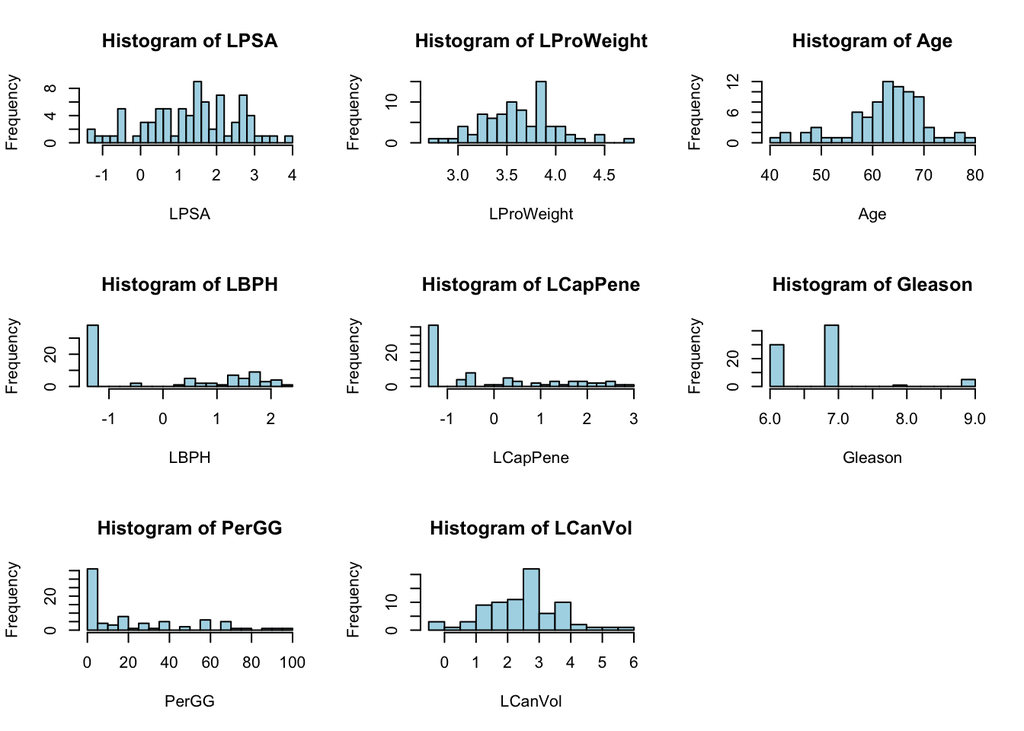

The correlation plot indicates that the predictor variable has strong linear associations with CapPene and LCanVol. In addition, emVelnv and CapPene and Gleason and PerGG have strong linear associations, which may cause a multicollinearity issue.

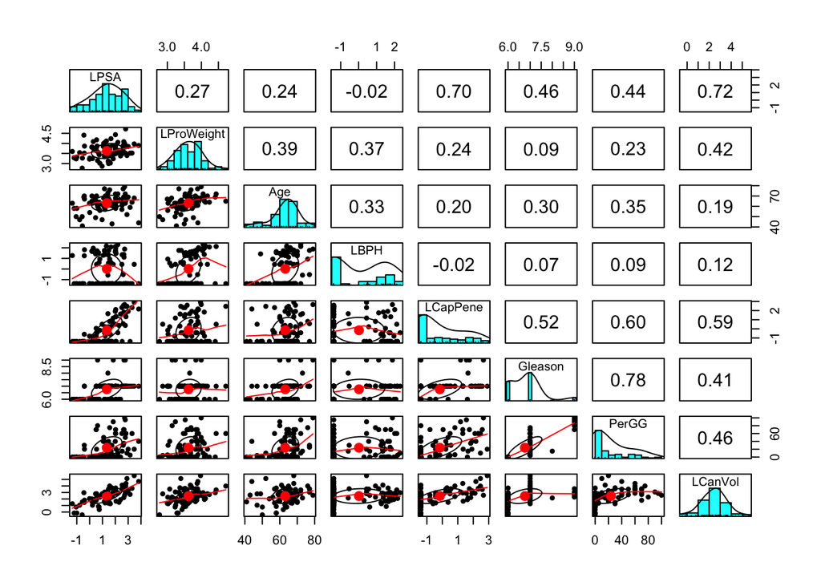

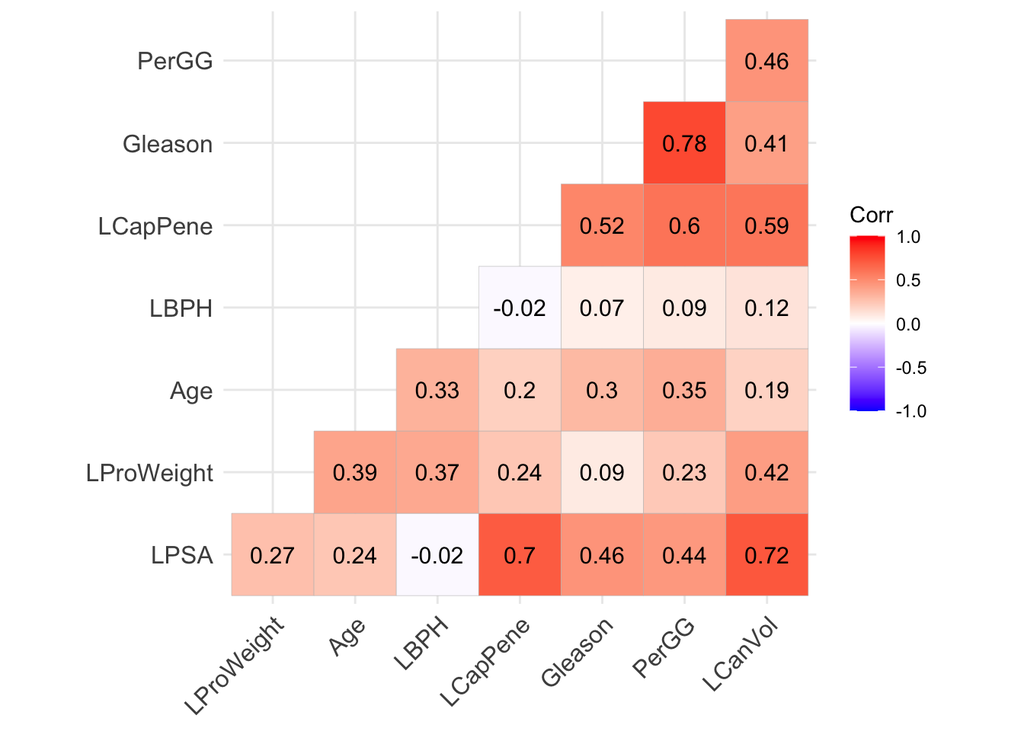

Simple linear regression is used to discover beta coefficients for each model. This is a univariate approach that helps to visualize any linear relationship existing between the reponse and the prector variables, before utilizing the mutiple linear model.

Coefficient of LProWeight

|  | Estimate | Std. Error | t value | Pr(>\|t\|) |
| --- | --- | --- | --- | --- |
| (Intercept) | -1.8358 | 1.2784 | -1.44 | 0.1550 |
| LProWeight | 0.8756 | 0.3511 | 2.49 | 0.0147 |

Coefficient of Age

|  | Estimate | Std. Error | t value | Pr(>\|t\|) |
| --- | --- | --- | --- | --- |
| (Intercept) | -1.0115 | 1.0850 | -0.93 | 0.3541 |
| Age | 0.0372 | 0.0171 | 2.18 | 0.0323 |

Coefficient of LBPH

|  | Estimate | Std. Error | t value | Pr(>\|t\|) |
| --- | --- | --- | --- | --- |
| (Intercept) | 1.3368 | 0.1338 | 9.99 | 0.0000 |
| LBPH | -0.0198 | 0.0941 | -0.21 | 0.8340 |

Coefficient of SemVeInv

|  | Estimate | Std. Error | t value | Pr(>\|t\|) |
| --- | --- | --- | --- | --- |
| (Intercept) | 0.9873 | 0.1271 | 7.77 | 0.0000 |
| SemVeInv1 | 1.5518 | 0.2679 | 5.79 | 0.0000 |

Coefficient of LCapPene

|  | Estimate | Std. Error | t value | Pr(>\|t\|) |
| --- | --- | --- | --- | --- |
| (Intercept) | 1.4315 | 0.0966 | 14.82 | 0.0000 |
| LCapPene | 0.5887 | 0.0686 | 8.59 | 0.0000 |

Coefficient of Gleason

|  | Estimate | Std. Error | t value | Pr(>\|t\|) |
| --- | --- | --- | --- | --- |
| (Intercept) | -3.4660 | 1.0617 | -3.26 | 0.0016 |
| Gleason | 0.7102 | 0.1560 | 4.55 | 0.0000 |

Coefficient of PerGG

|  | Estimate | Std. Error | t value | Pr(>\|t\|) |
| --- | --- | --- | --- | --- |
| (Intercept) | 0.8953 | 0.1574 | 5.69 | 0.0000 |
| PerGG | 0.0186 | 0.0043 | 4.34 | 0.0000 |

Coefficient of LCanVol

|  | Estimate | Std. Error | t value | Pr(>\|t\|) |
| --- | --- | --- | --- | --- |
| (Intercept) | -0.5155 | 0.2196 | -2.35 | 0.0214 |
| LCanVol | 0.7569 | 0.0814 | 9.29 | 0.0000 |

Coefficient of LProWeight

|  | Estimate | Std. Error | t value | Pr(>\|t\|) |
| --- | --- | --- | --- | --- |
| (Intercept) | -1.8358 | 1.2784 | -1.44 | 0.1550 |
| LProWeight | 0.8756 | 0.3511 | 2.49 | 0.0147 |

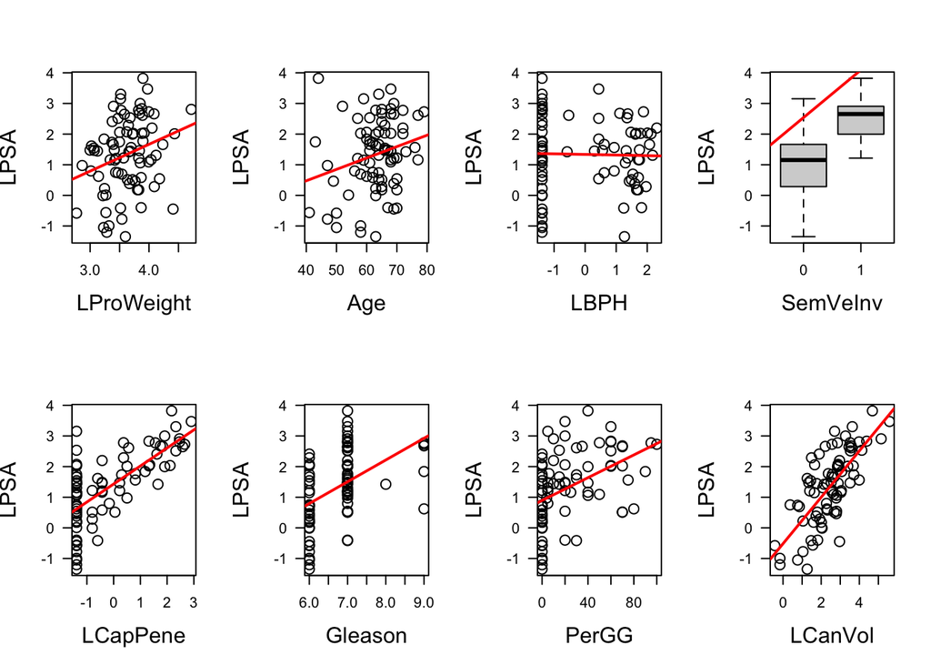

Box plots for SemVeInv and Gleason variables.

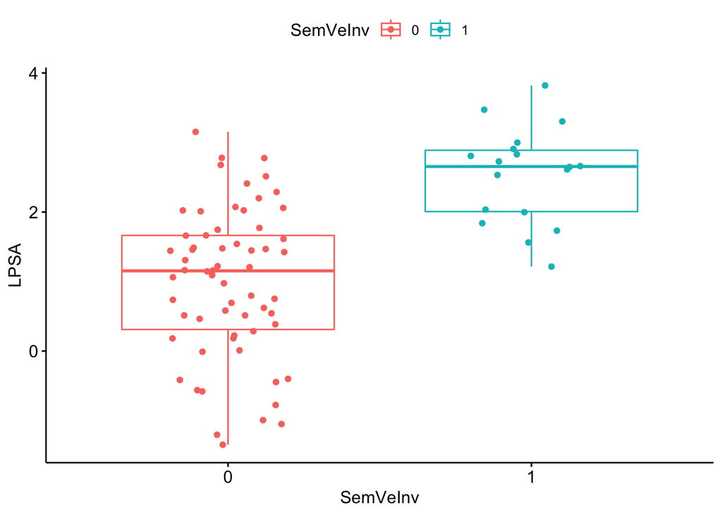

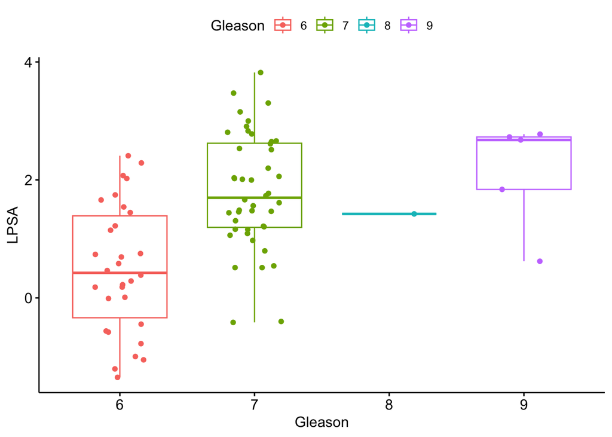

## Define the model

### Model selection

Automatic variable selection is employed to identify the best parsimonious model which should be considered.  
Three criterion are considered for the model selection. They consist of $C_p, BIC, adjR^2$.

| (Intercept) | LProWeight | Age | LBPH | SemVeInv1 | LCapPene | Gleason | PerGG | LCanVol | rss | adjr2 | cp | bic |
| --- | --- | --- | --- | --- | --- | --- | --- | --- | --- | --- | --- | --- |
| 1 | 0 | 0 | 0 | 0 | 0 | 0 | 0 | 1 | 53.0060 | 0.5194 | 25.1157 | -50.8704 |
| 1 | 0 | 0 | 0 | 0 | 1 | 0 | 0 | 1 | 40.3541 | 0.6294 | 2.9805 | -68.3054 |
| 1 | 0 | 0 | 1 | 0 | 1 | 0 | 0 | 1 | 39.7863 | 0.6298 | 3.8974 | -65.0569 |
| 1 | 0 | 1 | 1 | 0 | 1 | 0 | 0 | 1 | 38.7436 | 0.6347 | 3.9083 | -62.7994 |
| 1 | 0 | 1 | 0 | 0 | 1 | 1 | 1 | 1 | 38.3403 | 0.6336 | 5.1390 | -59.2545 |
| 1 | 0 | 1 | 1 | 0 | 1 | 1 | 1 | 1 | 37.3090 | 0.6385 | 5.1717 | -57.0538 |
| 1 | 1 | 1 | 1 | 0 | 1 | 1 | 1 | 1 | 37.2635 | 0.6340 | 7.0848 | -52.7696 |
| 1 | 1 | 1 | 1 | 1 | 1 | 1 | 1 | 1 | 37.2190 | 0.6293 | 9.0000 | -48.4830 |

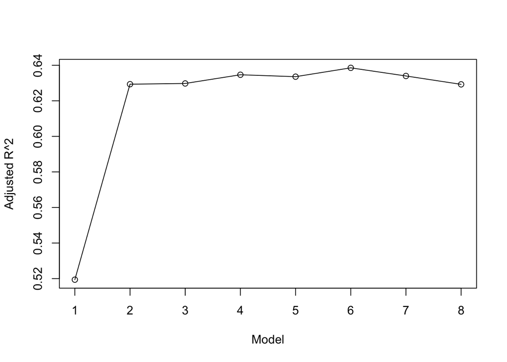

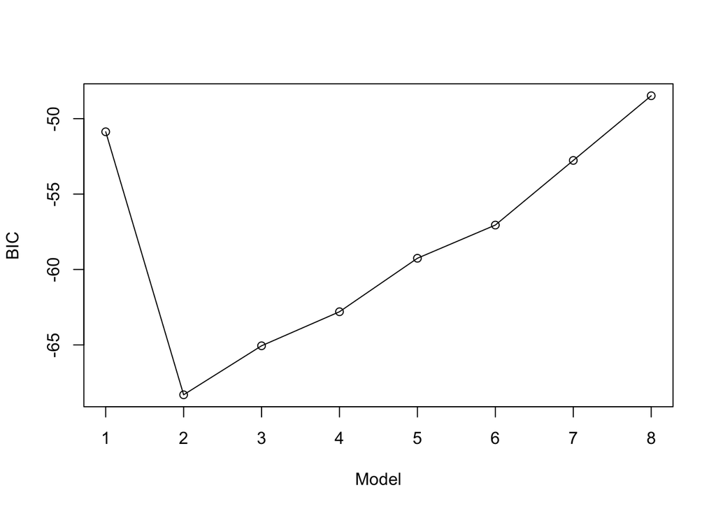

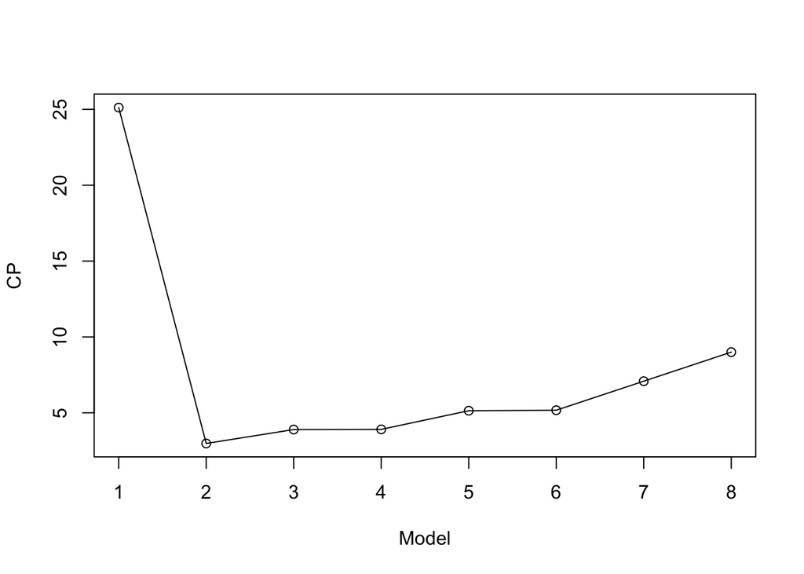

Anova analysis is performed to display statistically significant variables using F-test. As it displays, Age, LBPH, SemVeInv, LProweight, Gleason and PerGG variables don’t have statistically significant.

```
## Analysis of Variance Table
##
## Model 1: LPSA ~ LCapPene + LCanVol
## Model 2: LPSA ~ LProWeight + Age + LBPH + SemVeInv + LCapPene + Gleason +
##     PerGG + LCanVol
##   Res.Df    RSS Df Sum of Sq      F Pr(>F)
## 1     77 40.354
## 2     71 37.219  6     3.135 0.9967 0.4344
```

```
## Anova Table (Type III tests)
##
## Response: LPSA
##             Sum Sq Df F value    Pr(>F)
## (Intercept)  0.244  1  0.4648    0.4974
## LCapPene    12.652  1 24.1414 4.925e-06 ***
## LCanVol     17.064  1 32.5603 2.050e-07 ***
## Residuals   40.354 77
## ---
## Signif. codes:  0 '***' 0.001 '**' 0.01 '*' 0.05 '.' 0.1 ' ' 1
```

```
##
## Call:
## lm(formula = LPSA ~ LCapPene + LCanVol, data = train_df)
##
## Residuals:
##      Min       1Q   Median       3Q      Max
## -1.66041 -0.54263 -0.03626  0.59419  2.11661
##
## Coefficients:
##             Estimate Std. Error t value Pr(>|t|)
## (Intercept)  0.16157    0.23699   0.682    0.497
## LCapPene     0.35051    0.07134   4.913 4.93e-06 ***
## LCanVol      0.50331    0.08820   5.706 2.05e-07 ***
## ---
## Signif. codes:  0 '***' 0.001 '**' 0.01 '*' 0.05 '.' 0.1 ' ' 1
##
## Residual standard error: 0.7239 on 77 degrees of freedom
## Multiple R-squared:  0.6387, Adjusted R-squared:  0.6294
## F-statistic: 68.07 on 2 and 77 DF,  p-value: < 2.2e-16
```

### Model diagnosis

There are not any abnormality found in the plots. There doesn’t appear to be multicollinearity and other violation of linear regression assumptions.

### 1. Normality and VIF index

```
## LCapPene  LCanVol
## 1.520842 1.520842
```

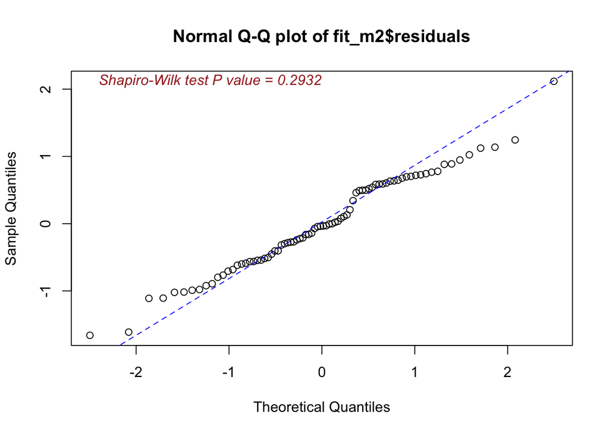

### 2. Plots for residual analysis

Nothing appears extreme or abnormal.

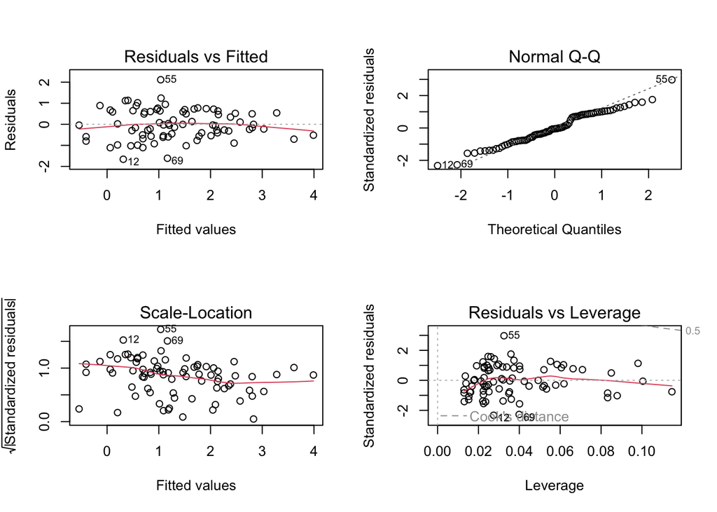

### Fit the model to the test dataset for the validation

MSPR is used to evaluate the prediction.

```
## [1] 1.073837e-29
```

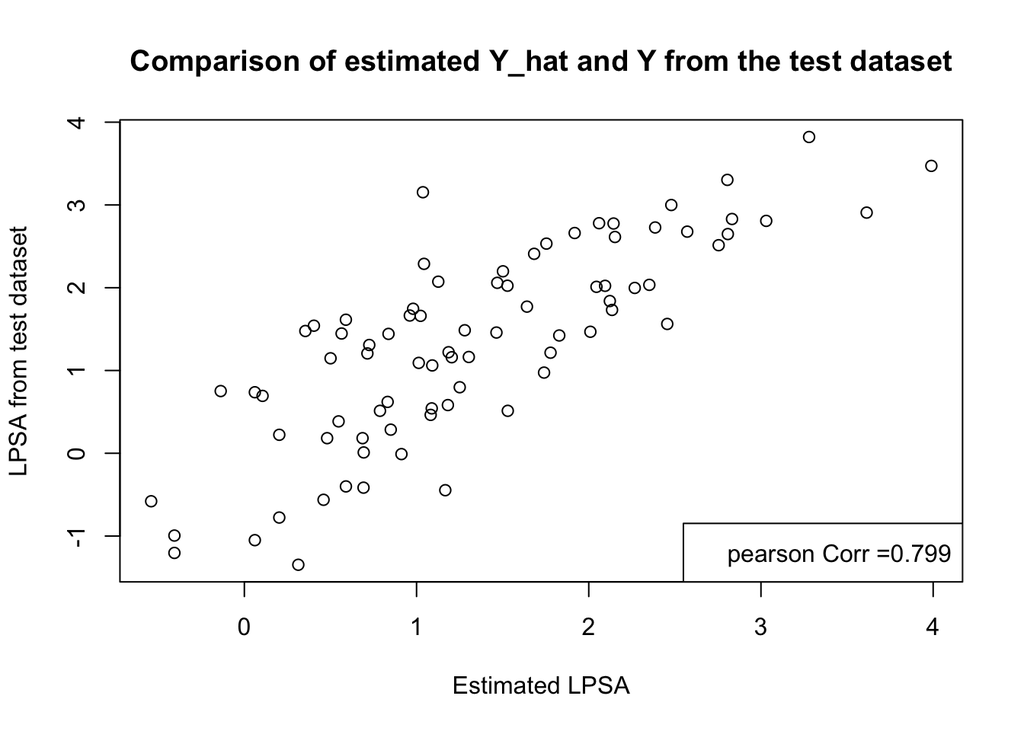